# Reconstrucción Ancestral de Secuencias - ACGCGCGT - NIES-4071

Eduardo PM

2023-03-30

Este pipeline es para hacer una reconstrucción ancestral de secuencias y crear un grafo con toda la información de las transiciones.

# Obtención de datos

En este pipe voy a utilizar un clado de 6 especies de calothrix:

| File | Accesion |
| --- | --- |
| Calothrix_sp_336-3_336-3.gbff | GCF_000734895.2 |
| Calothrix_sp_NIES-3974_NIES-3974.gbff | GCF_002368395.1 |
| Calothrix_sp_NIES-4071_NIES-4071.gbff | GCF_002368455.1 |
| Calothrix_sp_NIES-4105_NIES-4105.gbff | GCF_002368415.1 |
| Calothrix_sp_PCC_6303_PCC_6303.gbff | GCF_000317435.1 |
| Calothrix_sp_PCC_7716_PCC_7716.gbff | GCF_019977735.1 |

## Ortólogos

Primero obtengo los ortólogos usando **get_homologues**:

```bash
## /home/lalibelulalo/PIPELINES_2023/ASR_ORTHOLOGUES/Callothrix_clade/
get_homologues.pl -d gbff -t 0 -M -n PPN
```

Obtengo el pangenoma:

```bash
compare_clusters.pl -o pangenoma -m -d gbff_homologues/CalothrixspNIES-3974NIES-3974_f0_0taxa_algOMCL_e0_
```

Obtengo una lista de ortólogos (**orthologues.list**) la cual contenga solo aquellos en los que dicho ortólogo esta en las 6 especies del clado.

```bash
## /home/lalibelulalo/PIPELINES_2023/ASR_ORTHOLOGUES/Callothrix_clade/
awk -F "," '{if($15==1 && $16==1 && $17==1 && $18==1 && $19==1 && $20==1) {print $1}}' pangenoma/pangenome_matrix_t0.tr.csv | sed 's/.faa/.fna/g' >orthologues.list
```

## Conteo de palindromos

Hago un conteo de palindromos para saber cuales ortólogos contienen los palindromos de interés. Para eso uso **orthologues.list** y una lista con los palindromos de interes: **pals.list**.

Para esto uso parte del código del conteo de palindromos.

**Pals.list** contiene los palindromos a contar. Estos van en un a sola linea y separados por comas. El numero final corresponde al orden del modelo de markov (0-3) sin embargo es irrelevante para este paso ya que solo queremos saber el numero observado de palindromos.

```bash
## /home/lalibelulalo/PIPELINES_2023/ASR_ORTHOLOGUES/Callothrix_clade/
python3 CountPalsInOrthologues.py gbff_homologues/CalothrixspNIES-3974NIES-3974_f0_0taxa_algOMCL_e0_ pals.list orthologues.list 3
```

## Filtrado del conteo

```r
## /home/lalibelulalo/PIPELINES_2023/ASR_ORTHOLOGUES/Callothrix_clade/PALINDROMES/ACGCGCGT/
#setwd("/home/lalibelulalo/PIPELINES_2023/ASR_ORTHOLOGUES/Callothrix_clade/PALINDROMES/ACGCGCGT/")
Counts <- read.table("../../Markov_count_ACGCGCGT_2023-5-7_18hrs43mins_Octanuc_.txt", sep = "\t", header = TRUE)


Spp <- Counts$spp
Spp <- unique(Spp)

i=0
for (n in 1:length(Spp)){
  for (m in 1:length(Counts$spp)) {
    if (Spp[n] == Counts[m,2]){
      i=i+Counts[m,5]
    }
  }
  print(paste0(Spp[n]," ",i))
  i=0
}
```

```
## [1] "Calothrix_sp_336/3 1"
## [1] "Calothrix_sp_NIES-3974 1"
## [1] "Calothrix_sp_NIES-4071 269"
## [1] "Calothrix_sp_NIES-4105 269"
## [1] "Calothrix_sp_PCC_6303 0"
## [1] "Calothrix_sp_PCC_7716 162"
```

Aqui podemos ver que **NIES-4071** y **NIES-4105** son las que tienen mayores sitios (**269**) seguido de **Calothrix_sp_PCC_7716** con **162**.

```bash
## /home/lalibelulalo/PIPELINES_2023/ASR_ORTHOLOGUES/Callothrix_clade/PALINDROMES/ACGCGCGT/
awk '{if ($5>=1 && $2=="Calothrix_sp_NIES-4071"){print $1}}' ../../Markov_count_ACGCGCGT_2023-5-7_18hrs43mins_Octanuc_.txt >Ortologos_ACGCGCGT_Calothrix_sp_NIES-4071.txt
```

**Ortologos_ACGCGCGT_Calothrix_sp_NIES-4071.txt** contiene 368 ortólogos los cuales estan presentes en las 6 especies y tienen por lo menos una ocurrencia del palindromo **ACGCGCGT**

```bash
###
5352_secA.fna
5357_hypothetical_protein.fna
5358_OmpA_family_protein.fna
5369_HetZ-related_protein.fna
5382_DegT-DnrJ-EryC1-StrS...fna
5399_glycosyltransferase_...fna
5404_ftsH3.fna
5404_ftsH3.fna
5404_ftsH3.fna
5434_hypothetical_protein.fna
###
```

# Preparación de ortólogos para la alineción

Primero creo una carpeta que contendrá unicamente los ortologos que vamos a usar. Es decir aquellos que estan presentes en todas las especies a analizar y que contienen por lo menos un sitio con palíndromo.

```bash
## /home/lalibelulalo/PIPELINES_2023/ASR_ORTHOLOGUES/Callothrix_clade/PALINDROMES/ACGCGCGT/
mkdir Orthologues_ACGCGCGT_NIES-4071  ## Creo Carpeta
cd ../../gbff_homologues/CalothrixspNIES-3974NIES-3974_f0_0taxa_algOMCL_e0_ ## Entro a la carpeta de homólogos
for word in $(cat ../../PALINDROMES/ACGCGCGT/Ortologos_ACGCGCGT_Calothrix_sp_NIES-4071.txt); do cp $word ../../PALINDROMES/ACGCGCGT/Orthologues_ACGCGCGT_NIES-4071; done ## copio los ortólogos de la lista a la carpeta
```

## Filtrado de paralogos

voy a crear dos carpetas una que contenga archivos con paralogos y otra que solo tenga ortólogos

```bash
cd ../../PALINDROMES/ACGCGCGT/
mkdir Only_ORTHOLOGUES
mkdir PARALOGUES
```

Para filtrar aquellos con paralogos uso el siguiente script de python:

```python
from Bio import SeqIO
import re
import os
import sys
import shutil

SEQUENCES_PATH = sys.argv[1] #'Orthologues_GCGATCGC_336_3/' ## Path de la carpeta con los ortólogos.
#output_file = 'Orthologues_Palindrome_sites.txt' ## Nombre del archivo de salida
#output = open (output_file, 'w') ## Abrimos el archivo de salida

if SEQUENCES_PATH.endswith("/"): ## Esta parte la pongo por si corro este codigo en la terminal
    SequencesPath = re.sub('/', '', SEQUENCES_PATH) ## De este modo evito errores en el argumento path
    SequencesDir = str(SEQUENCES_PATH)
else:
    SequencesPath = SEQUENCES_PATH
    SequencesDir = str("".join ([SEQUENCES_PATH,'/']))
Orthologues = [x for x in os.listdir(SequencesDir) if x.endswith(".fna")] ## creo un arreglo con todos los ortólogis de la carpeta

for Orthologue in Orthologues:
    i = 0
    FNA = str("".join ([SequencesDir,Orthologue])) ## creo el path completo con el path de la carpeta de ortólogos y el path del ortólogo
    for record in SeqIO.parse(open(FNA),'fasta'):
        i += 1
    #print ('{}\t{}'.format(Orthologue,i))
    if i == 6:
        shutil.copyfile(FNA,str("".join (['Only_ORTHOLOGUES/',Orthologue]))) ## si hasy unicamente 6 entradas entonces no hay paralogos
    else:
        shutil.copyfile(FNA,str("".join (['PARALOGUES/',Orthologue]))) ## Si hay mas de 6 entradas hay parálogos
```

```python
python3 ../../FiltradoParalogos.py Orthologues_ACGCGCGT_NIES-4071/
```

Esto me dio como resultado 295 archivos sin paralogos y 56 archivos con paralogos los cuals omitiré por ahora.

Ahora edito el archivo fasta para que el encabezado incluya unicamente la especie

```bash
## /home/lalibelulalo/PIPELINES_2023/ASR_ORTHOLOGUES/Callothrix_clade/PALINDROMES/ACGCGCGT/Only_ORTHOLOGUES/
cd Only_ORTHOLOGUES
for f in *.fna; do awk -F "|" '{if (NR%2){print ">"$2}else{print $1}}' $f | sed 's/ /_/g' | sed 's/\.//g' | sed 's/\[//g' | sed 's/\]//g' | sed 's/\//-/g' | sed 's/Calothrix_sp_//g' >$f.awk1;done
```

## Alineación Múltiple

Hago la alineación multiple con **MAFFT**

```bash
## /home/lalibelulalo/PIPELINES_2023/ASR_ORTHOLOGUES/Callothrix_clade/PALINDROMES/ACGCGCGT/Only_ORTHOLOGUES/
for f in *.awk1; do mafft $f >$f.mafft;done
```

## Cambio de fasta a PHYLIP

```bash
## /home/lalibelulalo/PIPELINES_2023/ASR_ORTHOLOGUES/Callothrix_clade/PALINDROMES/ACGCGCGT/
cd ..
python3 ../../Fasta2Phylip.py Only_ORTHOLOGUES/
```

Obtengo las coordenadas del palindromo en la alineación usando el siguiente codigo de python:

```python
from Bio import SeqIO
import re
import os
import sys

SEQUENCES_PATH = sys.argv[1] #'Only_ORTHOLOGUES/' #
pattern = sys.argv[2] #'GCGATCGC' #
SPP = sys.argv[3] #'336-3' #
#SEQUENCES_PATH = 'gbff/Only_ORTHOLOGUES/' ## Path de la carpeta con los ortólogos.

output_file = 'Orthologues_Palindrome_sites.txt' ## Nombre del archivo de salida
output = open (output_file, 'w') ## Abrimos el archivo de salida
output.write('FILE\tPAL\tSTART\tEND\n')

if SEQUENCES_PATH.endswith("/"): ## Esta parte la pongo por si corro este codigo en la terminal
    SequencesPath = re.sub('/', '', SEQUENCES_PATH) ## De este modo evito errores en el argumento path
    SequencesDir = str(SEQUENCES_PATH)
else:
    SequencesPath = SEQUENCES_PATH
    SequencesDir = str("".join ([SEQUENCES_PATH,'/']))
Orthologues = [x for x in os.listdir(SequencesDir) if x.endswith(".phy")] ## creo un arreglo con todos los ortólogis de la carpeta
#pattern = '[cC][-]*[gG][-]*[gG][-]*[cC][-]*[gG][-]*[cC][-]*[cC][-]*[gG]'
pattern = re.sub('G', '[gG][-]*', pattern)
pattern = re.sub('C', '[cC][-]*', pattern)
pattern = re.sub('T', '[tT][-]*', pattern)
pattern = re.sub('A', '[aA][-]*', pattern)
pattern = pattern[:-4]
#pattern
j=0
k=0
for Orthologue in Orthologues:
    FNA = str("".join ([SequencesDir,Orthologue])) ## creo el path completo con el path de la carpeta de ortólogos y el path del ortólogo
    for record in SeqIO.parse(open(FNA),'phylip'):
        Seq = str(record.seq)
        Spp = record.description
        i = 0
        if Spp == SPP:#PCC_6303_PCC_6303 336-3_336-3
            for match in re.finditer(pattern, Seq):
                i += 1
                j += 1
                site = match.group()
                start = match.span()[0]
                end = match.span()[1]
                if len(site)==8:
                    k += 1
                    print ('{}\t{}\t{}\t{}:{}'.format(i,Orthologue,site,start+1,end))
                    output.write('{}\t{}\t{}\t{}\n'.format(Orthologue,site,start+1,end))
    print ('_________________________________________________________________________\n')
output.close()
print ("TOTAL: {} sitios".format(k))
```

```python
python3 ../../AlignmentPalindromeCoords.py Only_ORTHOLOGUES/ ACGCGCGT NIES-4071
```

```
###
FILE    PAL START   END
7693_transcriptional_repr...fna.awk1.mafft.phy  acgcgcgt    393 400
7299_alpha-D-glucose_phos...fna.awk1.mafft.phy  acgcgcgt    238 245
7299_alpha-D-glucose_phos...fna.awk1.mafft.phy  acgcgcgt    662 669
7819_alpha-beta_fold_hydr...fna.awk1.mafft.phy  acgcgcgt    435 442
8202_GspE-PulE_family_pro...fna.awk1.mafft.phy  acgcgcgt    1284    1291
7764_F0F1_ATP_synthase_su...fna.awk1.mafft.phy  acgcgcgt    203 210
9591_ABC_transporter_ATP-...fna.awk1.mafft.phy  acgcgcgt    434 441
6207_ABC_transporter_ATP-...fna.awk1.mafft.phy  acgcgcgt    985 992
8091_NDP-sugar_synthase.fna.awk1.mafft.phy  acgcgcgt    1088    1095
... etc
###
```

# GRAFO

primero cargo las librerias necesarias

```r
library(ggplot2)
library(ggtree)
library(ape)
library(tidyverse)
library(tidytree)
library(phangorn)
library(dplyr)
```

## Preparacion de datos para el grafo

Primero cargo **Orthologues_Palindrome_sites.txt** del paso anterior.

```r
## /home/lalibelulalo/PIPELINES_2023/ASR_ORTHOLOGUES/Callothrix_clade/PALINDROMES/ACGCGCGT/
Sites <- read.table("Orthologues_Palindrome_sites.txt", sep = "\t", header = TRUE)
```

Creo la matriz que va a contener unicamente las transiciones

```r
DF <- matrix(0,
             nrow = 0,
             ncol = 2)
colnames(DF) <- c("from","to")
```

Creo una matriz adicional que tendra las transiciones y una columna extra con la direccion de la transición

```r
{LINKS <- matrix(0,
             nrow = 0,
             ncol = 3)
colnames(LINKS) <- c("from","to","direction")}
```

Creo una matriz adicional que tendra las deleciones:

```r
{DELECIONES <- matrix(0,
                     nrow = 0,
                     ncol = 4)
colnames(DELECIONES) <- c("ortólogo","sitio","deleciones","species")}
```

Cargo el **modelo de evolucion**, el metodo de reconstrucción (**bayesiano**), la **filogenia** (previamente calculada con **orthofinder**).

```r
EvolModel = "F81"
Method = "bayes"
Tree = read.tree("../../SpeciesTree_rooted.txt")#"SpeciesTree_rooted.txt"
#Root = '336-3'
#Tree <-root(Tree, outgroup = Root, edgelabel = TRUE)
```

Esta filogenia contiene 11 nodos, sin embargo posteriormente para el analisis se quita la raiz y quedan 10.

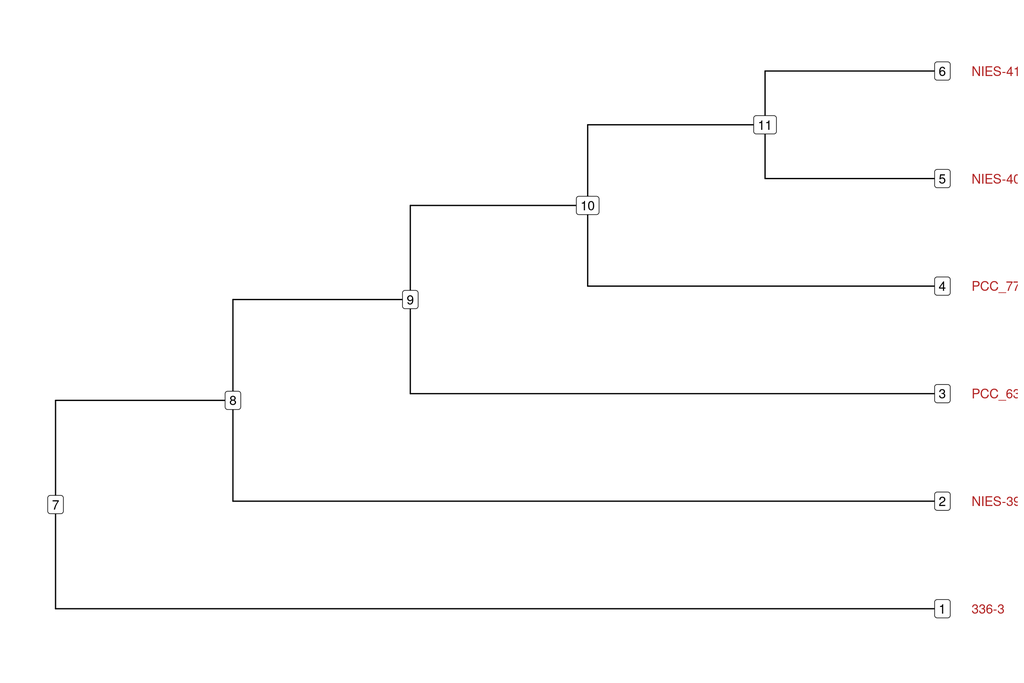

```r
ggtree(Tree,branch.length="none",) +
  geom_tiplab(color='firebrick', offset = .14)+
  geom_label(aes(label = node),show.legend = FALSE)
```

En el archivo **Orthologues_Palindrome_sites.txt** hay 200 sitios en total. Cargamos el primer sitio el cual corresponde a:

[output not shown]

El numero **ORTH** correponde al numero de sitio. Por lo tanto cargamos el PATH del alineamiento del primer sitio (**Alignment**), así como su inicio (**SI**) y su termino (**EI**)

```r
ORTH = 1
Alignment = paste0("Only_ORTHOLOGUES/",Sites[ORTH,1])
SI = Sites[ORTH,3]
EI = Sites[ORTH,4]
```

## Alineación multiple

Cargo la alineación multiple

```r
cyanobacterias <- read.phyDat(Alignment, format = "interleaved")

## Cambio el attributo site.patter a FALSE para poder acceder a todos los indices
cyanobacterias <- subset(cyanobacterias, site.pattern = FALSE)
#TreeR = pratchet(cyanobacterias, trace = 0)|>acctran(cyanobacterias)
parsimony(Tree, cyanobacterias)
```

```
## [1] 302
```

## Filogenia y parametros del modelo

Estimo los parametros para el modelo. en esta parte uso el modelo de evolucion elegido anteriormente (“F81”). Además en esta parte el arbol se desenraiza y ahora tenemos 10 nodos. Por lo tanto, debo cambiar el arbol al nuevo sin raiz para evitar errores.

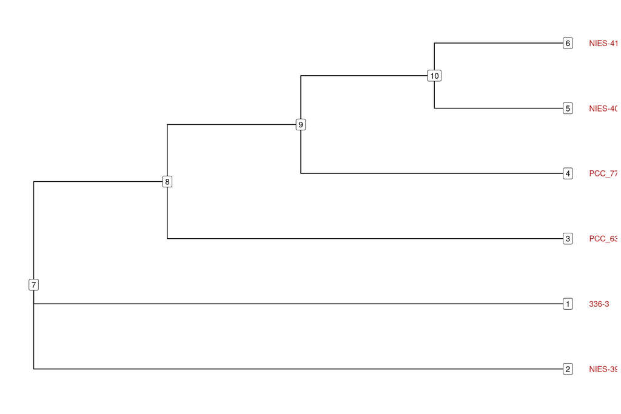

```r
fit <- pml(Tree, cyanobacterias)
fit <- optim.pml(fit, model=EvolModel, control = pml.control(trace=0))

Tree2 <- fit[["tree"]]
ggtree(Tree2,branch.length="none",) +
  geom_tiplab(color='firebrick', offset = .14)+
  geom_label(aes(label = node),show.legend = FALSE)
```

## Reconstrucción de Estados Ancestrales

Hago la reconstruccion de estados ancestrales para cada sitio. Para esto hay dos métodos: **bayesiano** o **máxima verosimilitud**. Anteriormente habia declarado la variable **Method** como bayes.

```r
  ## Calculo la probabilidad del árbol filogenético dado el alineamiento y el modelo
  if(Method == "bayes"){
    anc.bayes <- ancestral.pml(fit, type="bayes", return = "prob")
    Reconstruction <- anc.bayes
  }
  if(Method == "ml"){
    anc.ml <- ancestral.pml(fit, "ml")
    Reconstruction <- anc.ml
  }
```

## Armado de palindromos ancestrales

Armo los palindromos ancestrales de acuerdo a los estados ancestrales usando los sitios de inicio y fin de cada sitio palindromico (**SI** y **EI**). Posteriormente uso dicho intervalo para buscar lel estado de cada nucleotido del intervalo y guardarlo en el vector (**PalindromeNucleotidePositions**). Tambien extraigo los nombres de cada nodo de la reconstrucción:

```r
PalInterval = SI:EI ## ESTE ES EL INTERVALO DEL SITIO PALINDROMICO

## Obtengo las posiciones para la posicion PalInterval
PalindromeNucleotidePositions <- attributes(cyanobacterias)$index[PalInterval]

## Nombre de los nodos
Nodos <- attributes(Reconstruction)$names
```

Ahora creo una matriz que contendra 9 columnas, la primera contendrá los **Nodos** y las 8 restantes contendran los nucleotidos correspondientes a su palindromo y prosigo a rellenar la matriz. Sin embargo, en este paso hay un detalle.

La reconstrucción de estado ancestral para cada sitio arroja una probabilidad para cada uno de los 4 sitios posibles (**A**, **T** ,**G** o **C**). Si hay equivalencia en la probabilidad en los estados, es decir que el estado ancestral de un nucleotido tenga la misma probabilidad de haber estado en cualesquiera de los 4 posibles estados, entonces dicho estado se omite, de lo contrario se toma aquel estado con la mayor probabilidad. Otro punto importante es que hay sitios en los que una especie puede contener deleciones. Para estos casos, si gfalta algún nucleotido sew rellena con un “**-**”.

```r
  ## Transformo el arbol en data frame para extraer las etiquetas de los nodos.
  a.1 <- as_tibble(Tree2)

  ## NA.NODE corresponde al nodo a partir del cual ya no estan las puntas del arbol
  NA.NODE = length(cyanobacterias)+1

  ## Esto es para agregar la etiqueta de los nodos a los que faltan, es decir a los nodos que no son puntas del arbol.
  for (i in NA.NODE:length(Nodos)){ ## ESTO DEPENDE DE LA ESTRUCTURA DEL ARBOL
    a.1$label[i] <- a.1$node[i] # x$node[i-1]
  }

  ## Agrego las etiquetas de nodo al arbol
  b.1 <- tibble::tibble(label = Nodos)
  c.1 <- full_join(a.1, b.1, by = 'label')
  NodeLabels <- c.1$label

  TipLabels <- Tree2$tip.label
  NodeLabels2 <- NodeLabels[-c(1:length(TipLabels))]

  ## Creo una matriz de 8 x length(Nodos) (8 nucleotidos x numero de nodos) para guardar los resultados
  ScoresMtx <- matrix(0,
                      nrow = length(Nodos),
                      ncol = 8)
  colnames(ScoresMtx) <- c("1","2","3","4","5","6","7","8")
  rownames(ScoresMtx) <- Nodos


  ## Relleno la matriz con los scores.
  ## ESTE CICLO ES UNICAMENTE PARA LAS PUNTAS DE LOS NODOS
  j = 1
  i = 1
  k = 0
  for (Position in PalindromeNucleotidePositions){
    for (Nodo in TipLabels){
      PositionScores <- Reconstruction[[Nodo]][Position,] ## Extraigo los scores para el nodo "NODO" en la posicion "POSITION" de la secuencia
      if (length(unique(PositionScores)) == 1){
        k=k+1
        WinnerNucleotide = "-"
        ScoresMtx[i,j] <- WinnerNucleotide
        i=i+1 ## contador para cada Nodo
      }else{
        PositionWinnerScore <- max(PositionScores) ## Extraigo el valor mas grande. Este es el valor de la probabilidad de que el nucleotido ancestral sea ese
        WinnerNucleotide <- which(PositionScores == PositionWinnerScore, arr.ind = T) ## pregunto a que numero (Nucleótido) corresponde ese valor
        ScoresMtx[i,j] <- WinnerNucleotide ## Guardo dicho valor en la matriz de resultados
        i=i+1 ## contador para cada Nodo
      }
    }
    j=j+1 ## contador para cada posición
    i=1 ## Reiniciamoa el contador de Nodo para la siguiente posicion
  }

  ## Relleno la matriz con los scores
  ## ESTA PARTE ES PARA TODOS LOS NODOS RESTANTES QUE NO SON PUNTAS
  j = 1
  i = length(TipLabels)+1
  k = 0
  #(length(TipLabels)+1):length(NodeLabels)
  for (Position in PalindromeNucleotidePositions){
    for (Nodo in NodeLabels2){
      PositionScores <- Reconstruction[[Nodo]][Position,] ## Extraigo los scores para el nodo "NODO" en la posicion "POSITION" de la secuencia
      if (length(unique(PositionScores)) == 1){
        k=k+1
        WinnerNucleotide = "X"
        ScoresMtx[i,j] <- WinnerNucleotide
        i=i+1 ## contador para cada Nodo
      }else{
        PositionWinnerScore <- max(PositionScores) ## Extraigo el valor mas grande. Este es el valor de la probabilidad de que el nucleotido ancestral sea ese
        WinnerNucleotide <- which(PositionScores == PositionWinnerScore, arr.ind = T) ## pregunto a que numero (Nucleótido) corresponde ese valor
        ScoresMtx[i,j] <- WinnerNucleotide ## Guardo dicho valor en la matriz de resultados
        i=i+1 ## contador para cada Nodo
      }
    }
    j=j+1 ## contador para cada posición
    i=length(TipLabels)+1 ## Reiniciamoa el contador de Nodo para la siguiente posicion
  }
```

Ahora decodificamos el palindromo a nucleotidos para esto creo una nueva matriz que contendra dos columnas: nodos y sus correspondientes palíndromos.

```r
## Creo un matriz de 1x14 para guardar la etiqueta (palindromo) de cada nodo
PalsMtx <- matrix(0,
                  nrow = length(Nodos),
                  ncol = 1)
colnames(PalsMtx) <- c("Palindrome")
rownames(PalsMtx) <- Nodos

## Extraigo cada palindromo, cambio el codigo de numero por el codigo de letras y lo guardo en la matriz 1x14
i=0
j=0
for (Nodo in Nodos){
  j=j+1
  Palindrome <- as.character(ScoresMtx[j,]) # Este es el palindromo
  pal =""
  for (nuc in Palindrome){
    if(nuc== 1){nuc = 'A'}
    if(nuc== 2){nuc = 'C'}
    if(nuc== 3){nuc = 'G'}
    if(nuc== 4){nuc = 'T'}
    pal = paste(pal,nuc,sep = "")
  }
  PalsMtx[j,1] <- pal
}
```

Guardo los nodos y los palindromos de cada nodo en 2 vectores. Los cuales voy a usar para anotar el arbol filogenetico.

```r
l <- as.list(PalsMtx[,1])
Nodes = names(l)
NodePals = as.character(PalsMtx[,1])
```

## Anotacion del arbol filogenético

Para poder hacer esto, primero transformo el arbol filogenetico en una tabla y agrego 2 columnas: (**label**) que contendra el nombre de cada nodo y (**Palindromo**) que contendra el palindromo de dicho nodo.

```r
## Transformo el arbol en data frame para poder agregar los palindromos de cada nodo
x <- as_tibble(Tree2)

## Extraigo el Boostrap por si se ocupa
NA.NODE = length(cyanobacterias)+1
BootStrap <- x$label[NA.NODE:length(Nodes)]
for (i in NA.NODE:length(Nodes)){ ## ESTO DEPENDE DE LA ESTRUCTURA DEL ARBOL
  x$label[i] <- x$node[i] # x$node[i-1]
}
## Agrego los datos de los palindromos al arbol
d <- tibble::tibble(label = Nodes,
                    Palindromo = NodePals)
y <- full_join(x, d, by = 'label')
```

Hasta aqui tenemos una filogenoa anotada con su palindromo ancestral en cada nodo:

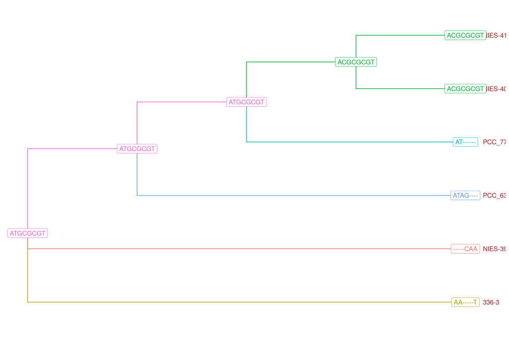

```r
ggtree(as.treedata(y),branch.length="none") +
    geom_tiplab(color='firebrick', offset = .14)+
    geom_label(aes(label = Palindromo,color=Palindromo),show.legend = FALSE)+
    aes(color=Palindromo)+
    guides(fill = guide_legend(override.aes = list(color = NA)),
           color = FALSE,
           shape = 1)
```

## Matriz de transiciones para el grafo

Ahora necesito crear una matriz que tenga las tranmsiciones entre cada nodo. Para esto extraigo las direcciones de los nodos desde el arbol filogenetico previamente anotado es decir las columnas **from** y **to** y las guardo en una nueva matriz:

```r
## Esta es la configuracion del arbol
from<-y$label#c("336-3","7","7","8","8","9","9","10","10")
to<-y$parent#c("7","NIES-3974","8","PCC_6303","9","PCC_7716","10","NIES-4071","NIES-4105")

LinksMtx <- matrix(0,
                   nrow = length(from),
                   ncol = 2)
colnames(LinksMtx) <- c("from","to")

for (i in 1:length(from)){
  LinksMtx[i,1] = from[i]
  LinksMtx[i,2] = to[i]
}
```

Luego extraigo las columnas **label** y **Palindromo** y las guardo en otra matriz. Dicha matriz me servira como diccionario para obtener las transiciones en cada nodo. Posteriormente la convierto a data frame.

```r
## AQUI VOY A CREAR LA MATRIZ QUE ME SERVIRA COMO DICCIONARIO PARA RELLENAR LA MATRIZ DE TRANSICIONES
Mat <- y[,4:5]

Mat2 <- as.data.frame(Mat) ## CONVIERTO A DF
Mat2
```

```
##        label Palindromo
## 1      336-3   AA-----T
## 2  NIES-3974   -----CAA
## 3   PCC_6303   ATAG----
## 4   PCC_7716   AT------
## 5  NIES-4071   ACGCGCGT
## 6  NIES-4105   ACGCGCGT
## 7          7   ATGCGCGT
## 8          8   ATGCGCGT
## 9          9   ATGCGCGT
## 10        10   ACGCGCGT
```

Hago un conteo de las deleciones y las guardo en un vector que contendrá el **ortologo**, **sitio** y **numero de deleciones**:

```r
  #~~~~~~~~~~~~~~~~~~~~~~~~
  d = 0
  SPP = c()
  for (i in 1:length(Mat2[,1])) {
    if(Mat2[i,2] == '--------'){
      d = d+1
      spp = Mat2[i,1]
      SPP = c(SPP,spp)
    }
  }
  Spp <- paste(SPP, collapse = ",")
  deleciones <-c()
  if(d != 0){
    print(paste0("Hay ",d," delecion(es) en el archivo ",Sites[ORTH,1],". Intervalo ",Sites[ORTH,3],":",Sites[ORTH,4],"."))
    SITE = paste0(Sites[ORTH,3],":",Sites[ORTH,4])
    deleciones <- c(Sites[ORTH,1],SITE,d,Spp)
  }
  #~~~~~~~~~~~~~~~~~~~~~~~~
```

Ahora creo una nueva matriz que va a tener todas las transiciones. Para esto uso las ultimas dos matrices. La matriz **LinksMtx** que tiene las direcciones entre nodos la paso a palindromos con ayuda de **Mat2** la cual me sirve como diccionario y convierto esta ultima matriz (**LinksMtx2**) a dataframe.

```r
## AQUI CREO LA MATRIZ DE TRANSICIONES.
LinksMtx2 <- matrix(0,
                    nrow = length(from),
                    ncol = 2)
colnames(LinksMtx2) <- c("from","to")

## AQUI RELLENO LA MATRIZ DE TRANSICIONES USANDO COMO DICCIONARIO A LA MATRIZ ANTERIOR (Mat2)
for (i in 1:length(from)) {
  for (j in 1:length(from)){
    if (LinksMtx[i,1]==Mat2[j,1]){
      LinksMtx2[i,1] = Mat2[j,2]
    }
    if (LinksMtx[i,2]==Mat2[j,1]){
      LinksMtx2[i,2] = Mat2[j,2]
    }
  }
}
df <- as.data.frame(LinksMtx2) ## CONVIERTO A DF LA MATRIZ DE TRANSICIONES
```

Creo una matriz adicional la cual es identica a la anterior salvo que le agrego las direcciones de cada transicion, las cuales podrian ser de utilidad.

```r
directions<-paste(from,to,sep="--") ## ESTE VECTOR CONTIENE LAS DIRECCIONES
Links0 = as.data.frame(LinksMtx2) ## HAGO UNA COPIA DE LA MATRIZ DE TRANSICIONES
Links0$direction<-directions ## AGREGO COMO COLUMNA NUEVA A "directions"
```

Al final de este paso tendre dos matrices **DF** y **LINKS**

**DF** contiene solo las transiciones

```r
DF <- rbind(DF,df) ## UNO LA MATRIZ ACTUAL DE TRANSICIONES CON LA ANTERIOR PARA CREAR UNA SOLA
DF
```

```
##        from       to
## 1  AA-----T ATGCGCGT
## 2  -----CAA ATGCGCGT
## 3  ATAG---- ATGCGCGT
## 4  AT------ ATGCGCGT
## 5  ACGCGCGT ACGCGCGT
## 6  ACGCGCGT ACGCGCGT
## 7  ATGCGCGT ATGCGCGT
## 8  ATGCGCGT ATGCGCGT
## 9  ATGCGCGT ATGCGCGT
## 10 ACGCGCGT ATGCGCGT
```

y **LINKS** las transiciones con sus respectivas direcciones.

```r
LINKS<-rbind(LINKS,Links0) ## UNO LA MATRIZ ACTUAL DE TRANSICIONES(CON DIRECCIONES) CON LA ANTERIOR PARA CREAR UNA SOLA
LINKS
```

```
##        from       to     direction
## 1  AA-----T ATGCGCGT      336-3--7
## 2  -----CAA ATGCGCGT  NIES-3974--7
## 3  ATAG---- ATGCGCGT   PCC_6303--8
## 4  AT------ ATGCGCGT   PCC_7716--9
## 5  ACGCGCGT ACGCGCGT NIES-4071--10
## 6  ACGCGCGT ACGCGCGT NIES-4105--10
## 7  ATGCGCGT ATGCGCGT          7--7
## 8  ATGCGCGT ATGCGCGT          8--7
## 9  ATGCGCGT ATGCGCGT          9--8
## 10 ACGCGCGT ATGCGCGT         10--9
```

**DELECIONES** tendrá las deleciones.

```r
DELECIONES <- rbind(DELECIONES,deleciones)
DELECIONES
```

```
##      ortólogo sitio deleciones species
```

```r
EvolModel = "F81"
Method = "bayes"
Tree = read.tree("../../SpeciesTree_rooted.txt")#"SpeciesTree_rooted.txt"
#Root = '336-3'
#Tree <-root(Tree, outgroup = Root, edgelabel = TRUE)

for (ORTH in 2:length(Sites[,1])){ ## HAY 2593 ortólogos
  Alignment = paste0("Only_ORTHOLOGUES/",Sites[ORTH,1])
  SI = Sites[ORTH,3]
  EI = Sites[ORTH,4]

  ## Cargo la alineación multiple
  cyanobacterias <- read.phyDat(Alignment, format = "interleaved")

  ## Cambio el attributo site.patter a FALSE para poder acceder a todos los indices
  cyanobacterias <- subset(cyanobacterias, site.pattern = FALSE)
  #TreeR = pratchet(cyanobacterias, trace = 0)|>acctran(cyanobacterias)
  parsimony(Tree, cyanobacterias)

  ## Estimo los parametros para el modelo
  fit <- pml(Tree, cyanobacterias)
  fit <- optim.pml(fit, model=EvolModel, control = pml.control(trace=0))

  Tree2 <- fit[["tree"]]

  ## Calculo la probabilidad del árbol filogenético dado el alineamiento y el modelo
  if(Method == "bayes"){
    anc.bayes <- ancestral.pml(fit, type="bayes", return = "prob")
    Reconstruction <- anc.bayes
  }
  if(Method == "ml"){
    anc.ml <- ancestral.pml(fit, "ml")
    Reconstruction <- anc.ml
  }

  #plotAnc(Tree2, anc.bayes, 1)
  PalInterval = SI:EI ## ESTE ES EL INTERVALO DEL SITIO PALINDROMICO

  ## Obtengo las posiciones para la posicion PalInterval
  PalindromeNucleotidePositions <- attributes(cyanobacterias)$index[PalInterval]

  ## Nombre de los nodos
  Nodos <- attributes(Reconstruction)$names

  ########################################################################################################
  ## Transformo el arbol en data frame para poder agregar los palindromos de cada nodo
  a.1 <- as_tibble(Tree2)
  ## Extraigo el Boostrap por si se ocupa
  NA.NODE = length(cyanobacterias)+1
  for (i in NA.NODE:length(Nodos)){ ## ESTO DEPENDE DE LA ESTRUCTURA DEL ARBOL
    a.1$label[i] <- a.1$node[i] # x$node[i-1]
  }
  ## Agrego los datos de los palindromos al arbol
  b.1 <- tibble::tibble(label = Nodos)
  c.1 <- full_join(a.1, b.1, by = 'label')
  NodeLabels <- c.1$label

  TipLabels <- Tree2$tip.label
  NodeLabels2 <- NodeLabels[-c(1:length(TipLabels))]

  ## Creo una matriz de 8 x length(Nodos) (8 nucleotidos, numero de nodos) para guardar los resultados
  ScoresMtx <- matrix(0,
                      nrow = length(Nodos),
                      ncol = 8)
  colnames(ScoresMtx) <- c("1","2","3","4","5","6","7","8")
  rownames(ScoresMtx) <- Nodos


  ## Relleno la matriz con los scores
  j = 1
  i = 1
  k = 0
  for (Position in PalindromeNucleotidePositions){
    for (Nodo in TipLabels){
      PositionScores <- Reconstruction[[Nodo]][Position,] ## Extraigo los scores para el nodo "NODO" en la posicion "POSITION" de la secuencia
      if (length(unique(PositionScores)) == 1){
        k=k+1
        WinnerNucleotide = "-"
        ScoresMtx[i,j] <- WinnerNucleotide
        i=i+1 ## contador para cada Nodo
      }else{
        PositionWinnerScore <- max(PositionScores) ## Extraigo el valor mas grande. Este es el valor de la probabilidad de que el nucleotido ancestral sea ese
        WinnerNucleotide <- which(PositionScores == PositionWinnerScore, arr.ind = T) ## pregunto a que numero (Nucleótido) corresponde ese valor
        ScoresMtx[i,j] <- WinnerNucleotide ## Guardo dicho valor en la matriz de resultados
        i=i+1 ## contador para cada Nodo
      }
    }
    j=j+1 ## contador para cada posición
    i=1 ## Reiniciamoa el contador de Nodo para la siguiente posicion
  }

  ## Relleno la matriz con los scores
  j = 1
  i = length(TipLabels)+1
  k = 0
  #(length(TipLabels)+1):length(NodeLabels)
  for (Position in PalindromeNucleotidePositions){
    for (Nodo in NodeLabels2){
      PositionScores <- Reconstruction[[Nodo]][Position,] ## Extraigo los scores para el nodo "NODO" en la posicion "POSITION" de la secuencia
      if (length(unique(PositionScores)) == 1){
        k=k+1
        WinnerNucleotide = "X"
        ScoresMtx[i,j] <- WinnerNucleotide
        i=i+1 ## contador para cada Nodo
      }else{
        PositionWinnerScore <- max(PositionScores) ## Extraigo el valor mas grande. Este es el valor de la probabilidad de que el nucleotido ancestral sea ese
        WinnerNucleotide <- which(PositionScores == PositionWinnerScore, arr.ind = T) ## pregunto a que numero (Nucleótido) corresponde ese valor
        ScoresMtx[i,j] <- WinnerNucleotide ## Guardo dicho valor en la matriz de resultados
        i=i+1 ## contador para cada Nodo
      }
    }
    j=j+1 ## contador para cada posición
    i=length(TipLabels)+1 ## Reiniciamoa el contador de Nodo para la siguiente posicion
  }
  ########################################################################################################

  ## EN ESTA PARTE ARMAREMOS EL PALINDROMO PARA CADA NODO

  ## Creo un matriz de 1x14 para guardar la etiqueta (palindromo) de cada nodo
  PalsMtx <- matrix(0,
                    nrow = length(Nodos),
                    ncol = 1)
  colnames(PalsMtx) <- c("Palindrome")
  rownames(PalsMtx) <- Nodos

  ## Extraigo cada palindromo, cambio el codigo de numero por el codigo de letras y lo guardo en la matriz 1x14
  i=0
  j=0
  for (Nodo in Nodos){
    j=j+1
    Palindrome <- as.character(ScoresMtx[j,]) # Este es el palindromo
    pal =""
    for (nuc in Palindrome){
      if(nuc== 1){nuc = 'A'}
      if(nuc== 2){nuc = 'C'}
      if(nuc== 3){nuc = 'G'}
      if(nuc== 4){nuc = 'T'}
      pal = paste(pal,nuc,sep = "")
    }
    PalsMtx[j,1] <- pal
  }

  ## ESTA PATRTE ES PARA GUARDAR LOS PALINDROMOS DE CADA NODO
  l <- as.list(PalsMtx[,1])
  Nodes = names(l)
  NodePals = as.character(PalsMtx[,1])

  ## Transformo el arbol en data frame para poder agregar los palindromos de cada nodo
  x <- as_tibble(Tree2)

  ## Extraigo el Boostrap por si se ocupa
  NA.NODE = length(cyanobacterias)+1
  BootStrap <- x$label[NA.NODE:length(Nodes)]
  for (i in NA.NODE:length(Nodes)){ ## ESTO DEPENDE DE LA ESTRUCTURA DEL ARBOL
    x$label[i] <- x$node[i] # x$node[i-1]
  }
  ## Agrego los datos de los palindromos al arbol
  d <- tibble::tibble(label = Nodes,
                      Palindromo = NodePals)
  y <- full_join(x, d, by = 'label')

  #------------------------

  ## Esta es la configuracion del arbol
  from<-y$label#c("336-3","7","7","8","8","9","9","10","10")
  to<-y$parent#c("7","NIES-3974","8","PCC_6303","9","PCC_7716","10","NIES-4071","NIES-4105")

  LinksMtx <- matrix(0,
                     nrow = length(from),
                     ncol = 2)
  colnames(LinksMtx) <- c("from","to")

  for (i in 1:length(from)){
    LinksMtx[i,1] = from[i]
    LinksMtx[i,2] = to[i]
  }

  ## AQUI VOY A CREAR LA MATRIZ QUE ME SERVIRA COMO DICCIONARIO PARA RELLENAR LA MATRIZ DE TRANSICIONES
  Mat <- y[,4:5]
  #Mat <- Mat %>% ## AQJUI QUITO EL RENGLON 7 QUE NO CONTIENE NADA. ESTE CORRESPONDE A LA RAIZ DEL ARBOL
  #  filter(!is.na(Palindromo))
  Mat

  Mat2 <- as.data.frame(Mat) ## CONVIERTO A DF
  Mat2

  #~~~~~~~~~~~~~~~~~~~~~~~~
  d = 0
  SPP = c()
  for (i in 1:length(Mat2[,1])) {
    if(Mat2[i,2] == '--------'){
      d = d+1
      spp = Mat2[i,1]
      SPP = c(SPP,spp)
    }
  }
  Spp <- paste(SPP, collapse = ",")
  deleciones <-c()
  if(d != 0){
    #print(paste0("Hay ",d," delecion(es) en el archivo ",Sites[ORTH,1],". Intervarlo ",Sites[ORTH,3],":",Sites[ORTH,4],"."))
    SITE = paste0(Sites[ORTH,3],":",Sites[ORTH,4])
    deleciones <- c(Sites[ORTH,1],SITE,d,Spp)
  }
  #~~~~~~~~~~~~~~~~~~~~~~~~

  ## AQUI CREO LA MATRIZ DE TRANSICIONES.
  LinksMtx2 <- matrix(0,
                      nrow = length(from),
                      ncol = 2)
  colnames(LinksMtx2) <- c("from","to")

  ## AQUI RELLENO LA MATRIZ DE TRANSICIONES USANDO COMO DICCIONARIO A LA MATRIZ ANTERIOR (Mat2)
  for (i in 1:length(from)) {
    for (j in 1:length(from)){
      if (LinksMtx[i,1]==Mat2[j,1]){
        LinksMtx2[i,1] = Mat2[j,2]
      }
      if (LinksMtx[i,2]==Mat2[j,1]){
        LinksMtx2[i,2] = Mat2[j,2]
      }
    }
  }

  directions<-paste(from,to,sep="--") ## ESTE VECTOR CONTIENE LAS DIRECCIONES
  Links0 = as.data.frame(LinksMtx2) ## HAGO UNA COPIA DE LA MATRIZ DE TRANSICIONES
  Links0$direction<-directions ## AGREGO COMO COLUMNA NUEVA A "directions"
  Links0
  LINKS<-rbind(LINKS,Links0) ## UNO LA MATRIZ ACTUAL DE TRANSICIONES(CON DIRECCIONES) CON LA ANTERIOR PARA CREAR UNA SOLA

  df <- as.data.frame(LinksMtx2) ## CONVIERTO A DF LA MATRIZ DE TRANSICIONES
  DF <- rbind(DF,df) ## UNO LA MATRIZ ACTUAL DE TRANSICIONES CON LA ANTERIOR PARA CREAR UNA SOLA
  #print(paste0("Archivo ",ORTH, " de ",length(Sites$FILE),"."))
  DELECIONES <- rbind(DELECIONES,deleciones)
}
length(DELECIONES[,1])
```

```
## [1] 3
```

```r
DELECIONES = as.data.frame(DELECIONES)
DELECIONES = DELECIONES[order(DELECIONES$deleciones,decreasing = TRUE),]
write.table(DELECIONES,file="DELECIONES.txt",sep="\t",row.names = FALSE,col.names = TRUE)

LINKS = as.data.frame(LINKS)
LINKS = LINKS[order(LINKS$direction),]
write.table(LINKS,file="edges.directions",sep="\t",row.names = FALSE,col.names = TRUE)
```

```r
File= "DELECIONES.txt"
table = read.table(File,header = TRUE,sep = "\t")
#knitr::kable(table, align = "lccrr")
rmarkdown::paged_table(table,options = list(rows.print = 10, cols.print = 4))
```

| ortólogo | sitio | deleciones | species |
| --- | --- | --- | --- |
| 9061_Uma2_family_endonucl...fna.awk1.mafft.phy | 723:730 | 4 | 336-3,NIES-3974,PCC_6303,PCC_7716 |
| 5724_ribD.fna.awk1.mafft.phy | 152:159 | 2 | NIES-3974,PCC_7716 |
| 9301_M48_family_metallopr...fna.awk1.mafft.phy | 296:303 | 1 | NIES-3974 |

```r
length(DF$from)
```

```
## [1] 2000
```

```r
length(LINKS$from)
```

```
## [1] 2000
```

```r
length(DELECIONES[,1])
```

```
## [1] 3
```

## Filtrado de datos para el GRAFO

```r
library(data.table)
RowCts <- setDT(DF)[,list(Count=as.numeric(.N)),names(DF)] ## CUENTO EL NUMERO DE OCURRENCIAS DE CADA TRANSICIÓN #7211
colnames(RowCts) <- c("from","to","weight")
RowCts = transform(RowCts, weight = as.integer(weight)) ## CONVIERTO A ENTEROS LA COLUMNA "weight"
RowCts <-as_tibble(RowCts) ## CONVIERTO A TIBBLE
RowCts #7211
```

```
## # A tibble: 847 × 3
##    from     to       weight
##    <chr>    <chr>     <int>
##  1 AA-----T ATGCGCGT      1
##  2 -----CAA ATGCGCGT      1
##  3 ATAG---- ATGCGCGT      1
##  4 AT------ ATGCGCGT      1
##  5 ACGCGCGT ACGCGCGT    568
##  6 ATGCGCGT ATGCGCGT     28
##  7 ACGCGCGT ATGCGCGT     14
##  8 GGTCAGGT GGTCGTGT      1
##  9 AGTTTAGT GGTCGTGT      1
## 10 GCCCGTGT GCTCGTGT      1
## # ℹ 837 more rows
```

```r
RowCts<-RowCts%>% ##QUITO LOS LOOPS. ES DECIR QUITO AQUELLAS TRANSICIONES QUE VAYAN ASI MISMA
  filter(from!=to)
length(RowCts$from) #5604
```

```
## [1] 693
```

```r
RowCts<-RowCts%>% ## QUIRO AQUELLAS TRANSICIONES CON UN PESO MENOR A 10
  filter(weight>=7)
length(RowCts$from) #63
```

```
## [1] 10
```

Extraigo todos los nodos posibles y los agrego a una matriz que va a contener los nodos del grafo. Adiconalmente le agrego una columna **score** que me indicara que tan parecido es el aplindromo a **HIP1** (despues la quito porque no creo que sea un buen índice)

```r
GraphNodes <- c(RowCts$from, RowCts$to) ## OBTENGO LOS PALINDROMOS DE CADA NODO
length(GraphNodes) #126
```

```
## [1] 20
```

```r
GNMtx <- matrix(0, ## CREO LA MATRIZ QUE CONTENDRÁ LAS NODOS PARA EL GRAFO
                nrow = length(GraphNodes),
                ncol = 2)
colnames(GNMtx) <- c("pal","score") ## ETIQUETO LAS COLUMNAS DE LA MATRIZ

for (i in 1:length(GraphNodes)){ ## RELLENO LA MATRIZ
  GNMtx[i,1] = GraphNodes[i] ## AGREGO LOS NODOS
  GNMtx[i,2] = RecordLinkage::levenshteinSim(GraphNodes[i], 'GCGATCGC')*1000 ## AGREGO UN SCORE QUE SERÁ EL PORCENTAJE DE IDENTIDAD CON HIP1 MULTIPLICADO POR 1000
}

GNMtx <- as.data.frame(GNMtx) ## CONVIERTO LA MATRIZ DE NODOS A DF
GNMtx <- GNMtx[!duplicated(GNMtx), ] ## ELIMINO LOS NODOS DUPLICADOS
```

Creo un vector que enumerará los palindromos. Dicha enumeracion correspondera a su **ID**

```r
palindromes<-GNMtx[,1] #34  ## EXTRAIGO LOS NODOS DE LA MATRIZ DEL GRAFO. ESTO LO HAGO PARA POSTERIAMENTE ENUMERARLAS Y ASOCIAR CADA NUMERO COMO ID

ids<-c() ## CREO UN VECTOR VACIO QUE CONTENDRÁ LOS ID'S
for (k in 1:length(palindromes)){ ## ENUMERO LOS PALINDROMOS. ESTOS NUMEROS SERAN LOS IDS
  ids <-append(ids, k)
}
ids
```

```
##  [1]  1  2  3  4  5  6  7  8  9 10
```

```r
length(ids) #34
```

```
## [1] 10
```

```r
length(GNMtx[,1]) #34
```

```
## [1] 10
```

Creo una matriz nueva que contendrá los nodos del grafo pero con su **ID** para cada palindromo:

```r
Nodes2 <-cbind(GNMtx,ids) ## CREO UNA MATRIZ NUEVA CON LA MATRIZ DE NODOS Y LOS IDS. ESTA LA VOY A USAR COMO UN DICCIONARIO ID-NODO
length(Nodes2$pal)
```

```
## [1] 10
```

```r
Nodes2<-Nodes2[,c(3,1,2)] ## REORDENO LAS COLUMNAS DE LA MATRIZ
colnames(Nodes2)<-c("id","label","score") ## ETIQUETO LAS COLUMNAS
```

Creo la matriz de vertices del grafo y tambien sustituyo el nombre de los nodos por sus respectivos **ID’S**. Adicionalmente cambio los scores que tengan 0 por 1’s ya que hay errores. Sin embargo, la columna score no la uso mas adelante.

```r
GEMtx <- RowCts ## ESTA VA A SER LA MATRIZ DE VERTICES
Edges2 <- as.matrix(RowCts)#RowCts ESTA ES OTRA MATRIZ DE VERTICES DE LA CUAL VOY A SUSTITUIR LOS NODOS POR SUS IDS

for (n in 1:length(Nodes2[,2])){ ##AQUI CAMBIARE LOS PALINDROMOS DE LOS NODOS POR IDS
  Edges2[Edges2==Nodes2[n,2]] <- as.numeric(Nodes2[n,1])
  #print(n)
}

for (n in 1:length(Nodes2[,2])){ ## HANDLE 0's
  Nodes2[Nodes2==0] <- as.numeric(1)
  #print(n)
}
```

# VISUALIZACIÓN DEL GRAFO

Cargo las librerias

```r
library(visNetwork)
library(networkD3)
library(tidygraph)
library(ggraph)
```

Para empezar cargo los **nodos** y los **vertices**. En esta parte quito la columna score de los nodos.

```r
nodes = as_tibble(Nodes2)
nodes = select(nodes, -score)

edges = as_tibble(Edges2)
edges = transform(edges, from = as.integer(from))
edges = transform(edges, to = as.integer(to))
edges = transform(edges, weight = as.integer(weight))
edges = as_tibble(edges)
```

Creo un grafo dirigido agregando un peso de acuerdo a la columna **weight**.

```r
routes_tidy <- tbl_graph(nodes = nodes,
                         edges = edges,
                         directed = TRUE)

routes_tidy
```

```
## # A tbl_graph: 10 nodes and 10 edges
## #
## # A directed simple graph with 1 component
## #
## # A tibble: 10 × 2
##      id label
##   <int> <chr>
## 1     1 ACGCGCGT
## 2     2 ACGCGCGC
## 3     3 ACGCACGT
## 4     4 ATGCGCGT
## 5     5 ACGCGCTT
## 6     6 ACGCTCGT
## # ℹ 4 more rows
## #
## # A tibble: 10 × 3
##    from    to weight
##   <int> <int>  <int>
## 1     1     4     14
## 2     2     1      7
## 3     1     5      8
## # ℹ 7 more rows
```

```r
routes_tidy %>%
  activate(edges) %>%
  arrange(desc(weight))
```

```
## # A tbl_graph: 10 nodes and 10 edges
## #
## # A directed simple graph with 1 component
## #
## # A tibble: 10 × 3
##    from    to weight
##   <int> <int>  <int>
## 1     1     4     14
## 2     1     8     12
## 3     1     3     11
## 4     1     9     11
## 5     1    10      9
## 6     1     5      8
## # ℹ 4 more rows
## #
## # A tibble: 10 × 2
##      id label
##   <int> <chr>
## 1     1 ACGCGCGT
## 2     2 ACGCGCGC
## 3     3 ACGCACGT
## # ℹ 7 more rows
```

Visualizo el grafo:

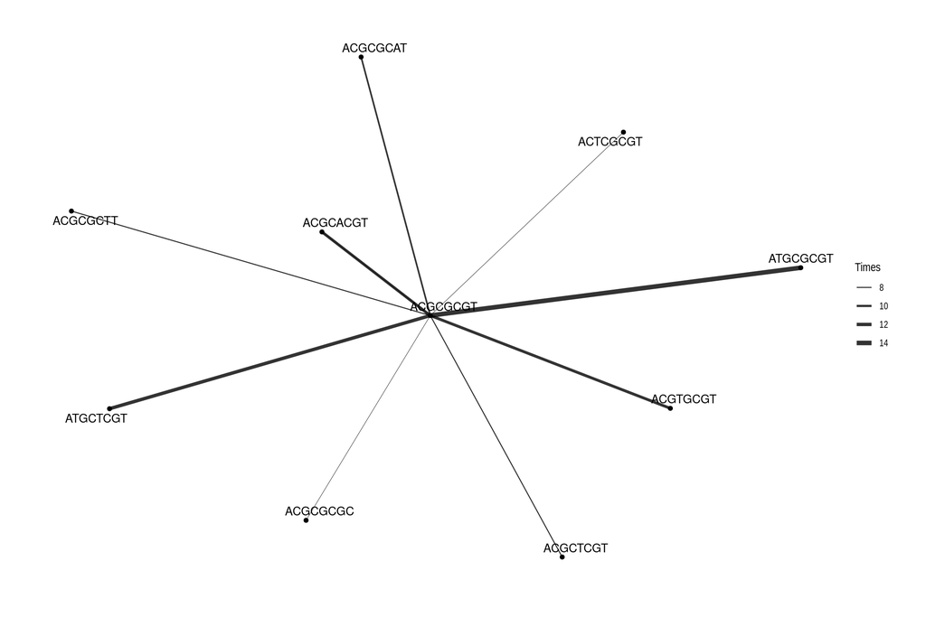

```r
ggraph(routes_tidy, layout = "graphopt") +
  geom_node_point() +
  geom_edge_link(aes(width = weight), alpha = 0.8) +
  scale_edge_width(range = c(0.2, 2)) +
  geom_node_text(aes(label = label), repel = TRUE) +
  labs(edge_width = "Times") +
  theme_graph()
```

## GRAFOS INTERACTIVOS

Este es un grafo sin peso en los vertices.

```r
visNetwork(nodes, edges)
```

[interactive chart not shown]

Este es el mismo grafo pero con peso en sus vertices

```r
edges <- mutate(edges, width = weight/5 + 1)
visNetwork(nodes, edges) %>%
  visIgraphLayout(layout = "layout_with_fr") %>%
  visEdges(arrows = "middle")
```

[interactive chart not shown]

Este es otro grafo de fuerzas con peso en sus vertices y te muestra las conceciones de cada nodo de manera mas visual

```r
nodes_d3 <- mutate(nodes, id = id - 1)
edges_d3 <- mutate(edges, from = from - 1, to = to - 1)

forceNetwork(Links = edges_d3, Nodes = nodes_d3,
             Source = "from", Target = "to",
             NodeID = "label", Group = "id", Value = "weight",
             opacity = 1, fontSize = 16, zoom = TRUE)
```

[interactive chart not shown]

Este ultimo grafo muestra el grafo anterior pero de una forma mas analizable.

```r
sankeyNetwork(Links = edges_d3, Nodes = nodes_d3, Source = "from", Target = "to",
              NodeID = "label", Value = "weight", fontSize = 16, unit = "TIME(s)")
```

[interactive chart not shown]

# GRAFOS POR **DIRECCION**

Las siguientes figuras corresponden a cada una de las direcciones.

```r
WGHT = 4

RowCtsL <- setDT(LINKS)[,list(Count=as.numeric(.N)),names(LINKS)] ## CUENTO EL NUMERO DE OCURRENCIAS DE CADA TRANSICIÓN #11520 ***
RowCtsLTEST <- setDT(LINKS)[,list(Count=as.numeric(.N)),names(LINKS)] ## CUENTO EL NUMERO DE OCURRENCIAS DE CADA TRANSICIÓN #11520 ***
colnames(RowCtsL) <- c("from","to","direction","weight") ## CAMBIO LA ETIQUETA "counts" A "weight" ***
RowCtsL = transform(RowCtsL, weight = as.integer(weight)) ## CONVIERTO A ENTEROS LA COLUMNA "weight" ***
RowCtsL <-as_tibble(RowCtsL) ## CONVIERTO A TIBBLE**
length(RowCtsL$from) #11520
```

```
## [1] 1132
```

```r
RowCtsL<-RowCtsL%>% ##QUITO LOS LOOPS. ES DECIR QUITO AQUELLAS TRANSICIONES QUE VAYAN ASI MISMA ***
  filter(from!=to)
#length(RowCtsL$from) #6380
RowCtsL<-RowCtsL%>% ## QUITO AQUELLAS TRANSICIONES CON UN PESO MENOR A 2 ***
  filter(weight>=1)

write.table(RowCtsLTEST,file="transiciones_dirección_counts.txt",sep="\t",row.names = FALSE,col.names = TRUE)
```

# **336-3–7** weight>=2

```r
ggtree(Tree2) +
  geom_tiplab(color='firebrick', offset = .10, hjust=3.0)+
  geom_label(aes(label = node),show.legend = TRUE)
```

```
## [1] 1132
```

```
## # A tbl_graph: 7 nodes and 7 edges
## #
## # A directed multigraph with 5 components
## #
## # A tibble: 7 × 4
##    from    to direction weight
##   <int> <int> <chr>      <int>
## 1     2     7 336-3--7       3
## 2     2     2 336-3--7       3
## 3     3     3 336-3--7       3
## 4     1     1 336-3--7       2
## 5     4     4 336-3--7       2
## 6     5     2 336-3--7       2
## # ℹ 1 more row
## #
## # A tibble: 7 × 2
##      id label
##   <int> <chr>
## 1     1 ATGCGCGG
## 2     2 ATGCTCGT
## 3     3 ACCCGTGT
## # ℹ 4 more rows
```

[interactive chart not shown]

# **NIES-3974–7**

```r
ggtree(Tree2) +
  geom_tiplab(color='firebrick', offset = .10, hjust=3.0)+
  geom_label(aes(label = node),show.legend = TRUE)
```

```
## [1] 1132
```

```
## # A tbl_graph: 1 nodes and 1 edges
## #
## # A directed multigraph with 1 component
## #
## # A tibble: 1 × 2
##      id label
##   <int> <chr>
## 1     1 ATGCTCGT
## #
## # A tibble: 1 × 4
##    from    to direction    weight
##   <int> <int> <chr>         <int>
## 1     1     1 NIES-3974--7      4
```

```
## # A tbl_graph: 1 nodes and 1 edges
## #
## # A directed multigraph with 1 component
## #
## # A tibble: 1 × 4
##    from    to direction    weight
##   <int> <int> <chr>         <int>
## 1     1     1 NIES-3974--7      4
## #
## # A tibble: 1 × 2
##      id label
##   <int> <chr>
## 1     1 ATGCTCGT
```

[interactive chart not shown]

# **NIES-4071–10** weight>=1 ONLY LOOPS

```r
ggtree(Tree2) +
  geom_tiplab(color='firebrick', offset = .10, hjust=3.0)+
  geom_label(aes(label = node),show.legend = TRUE)
```

```
## [1] 1132
```

```
## # A tbl_graph: 1 nodes and 1 edges
## #
## # A directed multigraph with 1 component
## #
## # A tibble: 1 × 4
##    from    to direction     weight
##   <int> <int> <chr>          <int>
## 1     1     1 NIES-4071--10    200
## #
## # A tibble: 1 × 2
##      id label
##   <int> <chr>
## 1     1 ACGCGCGT
```

[interactive chart not shown]

# **NIES-4105–10** weight>=1 ONLY LOOPS

```r
ggtree(Tree2) +
  geom_tiplab(color='firebrick', offset = .10, hjust=3.0)+
  geom_label(aes(label = node),show.legend = TRUE)
```

```
## [1] 1132
```

```
## # A tbl_graph: 1 nodes and 1 edges
## #
## # A directed multigraph with 1 component
## #
## # A tibble: 1 × 4
##    from    to direction     weight
##   <int> <int> <chr>          <int>
## 1     1     1 NIES-4105--10    200
## #
## # A tibble: 1 × 2
##      id label
##   <int> <chr>
## 1     1 ACGCGCGT
```

[interactive chart not shown]

# **PCC_6303–8**

```r
ggtree(Tree2) +
  geom_tiplab(color='firebrick', offset = .10, hjust=3.0)+
  geom_label(aes(label = node),show.legend = TRUE)
```

```
## [1] 1132
```

```
## # A tbl_graph: 2 nodes and 2 edges
## #
## # A directed multigraph with 2 components
## #
## # A tibble: 2 × 4
##    from    to direction   weight
##   <int> <int> <chr>        <int>
## 1     1     1 PCC_6303--8      6
## 2     2     2 PCC_6303--8      5
## #
## # A tibble: 2 × 2
##      id label
##   <int> <chr>
## 1     1 ATGCTCGT
## 2     2 ACGTGCTT
```

[interactive chart not shown]

# **PCC_7716–9**

```r
ggtree(Tree2) +
  geom_tiplab(color='firebrick', offset = .10, hjust=3.0)+
  geom_label(aes(label = node),show.legend = TRUE)
```

```
## [1] 1132
```

```
## # A tbl_graph: 6 nodes and 8 edges
## #
## # A directed multigraph with 3 components
## #
## # A tibble: 8 × 4
##    from    to direction   weight
##   <int> <int> <chr>        <int>
## 1     4     4 PCC_7716--9     61
## 2     1     4 PCC_7716--9      7
## 3     3     4 PCC_7716--9      7
## 4     2     2 PCC_7716--9      7
## 5     3     3 PCC_7716--9      6
## 6     2     4 PCC_7716--9      4
## # ℹ 2 more rows
## #
## # A tibble: 6 × 2
##      id label
##   <int> <chr>
## 1     1 ACGCGCGC
## 2     2 ACGTGCGT
## 3     3 ACGCACGT
## # ℹ 3 more rows
```

[interactive chart not shown]

# **10–9**

```r
ggtree(Tree2) +
  geom_tiplab(color='firebrick', offset = .10, hjust=3.0)+
  geom_label(aes(label = node),show.legend = TRUE)
```

```
## [1] 1132
```

```
## # A tbl_graph: 8 nodes and 8 edges
## #
## # A directed multigraph with 1 component
## #
## # A tibble: 8 × 4
##    from    to direction weight
##   <int> <int> <chr>      <int>
## 1     1     1 10--9         97
## 2     1     5 10--9         11
## 3     1     6 10--9         10
## 4     1     2 10--9          9
## 5     1     3 10--9          6
## 6     1     7 10--9          6
## # ℹ 2 more rows
## #
## # A tibble: 8 × 2
##      id label
##   <int> <chr>
## 1     1 ACGCGCGT
## 2     2 ATGCGCGT
## 3     3 ACGCGCTT
## # ℹ 5 more rows
```

[interactive chart not shown]

# **9–8**

```r
ggtree(Tree2) +
  geom_tiplab(color='firebrick', offset = .10, hjust=3.0)+
  geom_label(aes(label = node),show.legend = TRUE)
```

```
## [1] 1132
```

```
## # A tbl_graph: 7 nodes and 7 edges
## #
## # A directed multigraph with 3 components
## #
## # A tibble: 7 × 4
##    from    to direction weight
##   <int> <int> <chr>      <int>
## 1     2     2 9--8           8
## 2     2     6 9--8           8
## 3     2     5 9--8           6
## 4     1     1 9--8           5
## 5     2     1 9--8           5
## 6     3     7 9--8           5
## # ℹ 1 more row
## #
## # A tibble: 7 × 2
##      id label
##   <int> <chr>
## 1     1 ATGCGCGT
## 2     2 ACGCGCGT
## 3     3 ACGTGCGT
## # ℹ 4 more rows
```

[interactive chart not shown]

# **8–7**

```r
ggtree(Tree2) +
  geom_tiplab(color='firebrick', offset = .10, hjust=3.0)+
  geom_label(aes(label = node),show.legend = TRUE)
```

```
## [1] 1132
```

```
## # A tbl_graph: 6 nodes and 6 edges
## #
## # A directed multigraph with 6 components
## #
## # A tibble: 6 × 2
##      id label
##   <int> <chr>
## 1     1 ATGCGCGT
## 2     2 ACGGGCAT
## 3     3 ACGCTCGT
## 4     4 ACGTGCTT
## 5     5 ACCCGCGT
## 6     6 ATGCTCGT
## #
## # A tibble: 6 × 4
##    from    to direction weight
##   <int> <int> <chr>      <int>
## 1     1     1 8--7           8
## 2     2     2 8--7           4
## 3     3     3 8--7           4
## # ℹ 3 more rows
```

```
## # A tbl_graph: 6 nodes and 6 edges
## #
## # A directed multigraph with 6 components
## #
## # A tibble: 6 × 4
##    from    to direction weight
##   <int> <int> <chr>      <int>
## 1     6     6 8--7           9
## 2     1     1 8--7           8
## 3     4     4 8--7           6
## 4     2     2 8--7           4
## 5     3     3 8--7           4
## 6     5     5 8--7           4
## #
## # A tibble: 6 × 2
##      id label
##   <int> <chr>
## 1     1 ATGCGCGT
## 2     2 ACGGGCAT
## 3     3 ACGCTCGT
## # ℹ 3 more rows
```

[interactive chart not shown]